# Kerri Anderson

# Bar plots or violin plots for categorical variables

Next, let's examine each categorical variable by the target outcome variable. I will use the original variables for this analysis to get a general idea of trends.

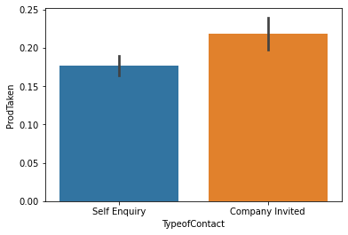

```python
sns.barplot(x=tour_orig["TypeofContact"], y=tour_orig["ProdTaken"])
```

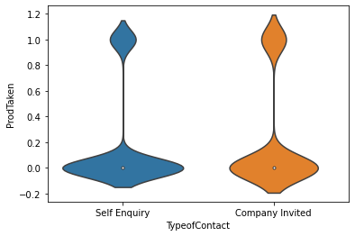

```python
sns.violinplot(x=tour_orig["TypeofContact"], y=tour_orig["ProdTaken"])
```

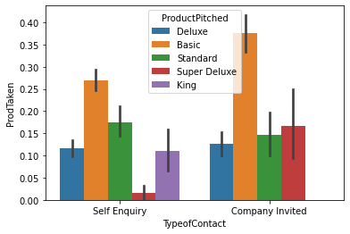

```python
sns.barplot(x=tour_orig.TypeofContact,y=tour_orig.ProdTaken,hue=tour_orig.ProductPitched)
```

If the company invited the customer, they were more likely to purchase a package. The initial reachout in marketing can be key to selling more packages.

The Basic and Super Deluxe packages show the most success when the company invites.

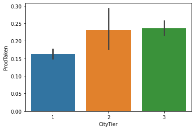

```python
sns.barplot(x=tour_orig["CityTier"], y=tour_orig["ProdTaken"])
```

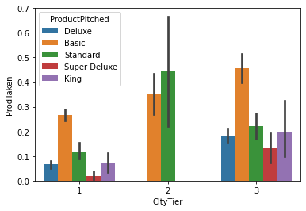

```python
sns.barplot(x=tour_orig.CityTier,y=tour_orig.ProdTaken,hue=tour_orig.ProductPitched)
```

Tier 1 cities are less likely than tier 2 or tier 3 citys to sell packages. It's not clear if this is the tier of the city the customer lives in, or the tier of the city being visited - would need clarification from the data owner on this.

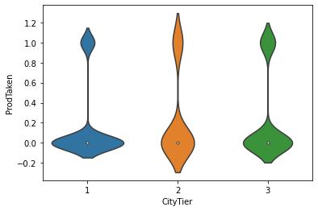

```python
sns.violinplot(x=tour_orig["CityTier"], y=tour_orig["ProdTaken"])
```

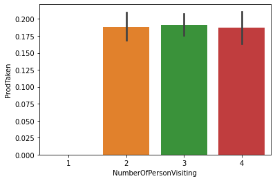

```python
sns.barplot(x=tour["NumberOfPersonVisiting"], y=tour["ProdTaken"])
```

```python
pd.crosstab(tour.NumberOfPersonVisiting,tour.ProdTaken)
```

| ProdTaken NumberOfPersonVisiting | 0 | 1 |
| --- | --- | --- |
| 1 | 39 | 0 |
| 2 | 1151 | 267 |
| 3 | 1942 | 460 |
| 4 | 836 | 193 |

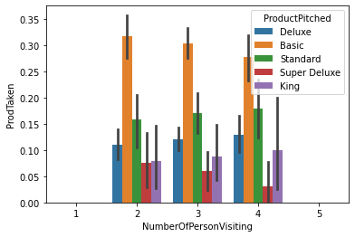

```python
sns.barplot(x=tour_orig.NumberOfPersonVisiting,y=tour_orig.ProdTaken,hue=tour_orig.ProductPitched)
```

The number of persons visiting does not appear to impact the purchasing of a package or not. The sample size of one person visiting may not be large enough to draw a solid conclusion, even though all of the examples of one person visiting did not purchase a package.

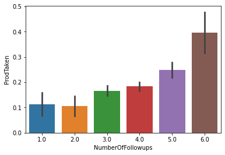

```python
sns.barplot(x=tour_orig["NumberOfFollowups"], y=tour_orig["ProdTaken"])
```

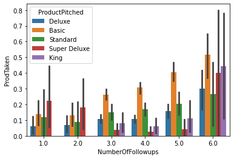

```python
sns.barplot(x=tour_orig.NumberOfFollowups,y=tour_orig.ProdTaken,hue=tour_orig.ProductPitched)
```

Increasing the number of follow-ups with customers does seem to increase the likelihood of a customer purchasing a package. this is important to note.

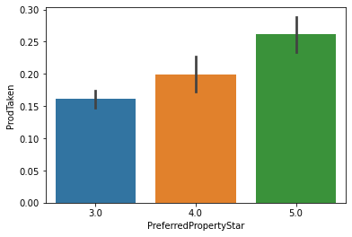

```python
sns.barplot(x=tour_orig["PreferredPropertyStar"], y=tour_orig["ProdTaken"])
```

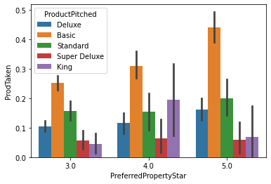

```python
sns.barplot(x=tour_orig.PreferredPropertyStar,y=tour_orig.ProdTaken,hue=tour_orig.ProductPitched)
```

Persons who preferred a higher property start tended to purchase a packagae more often.

For those who are pitched the King package, the most success is shown with 4 stars preferred.

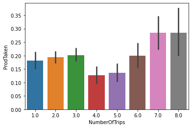

```python
sns.barplot(x=tour["NumberOfTrips"], y=tour["ProdTaken"])
```

This relationsip is interesting. It seems that those who take trips the most often are most likely to buy a package. This might be a convenience factor, to save on time planning. Also, those who travel less often are next most likely to purchase a package, as they might see traveling as a special ocassion and are looking to splurge a bit on their trips since they happen less often.

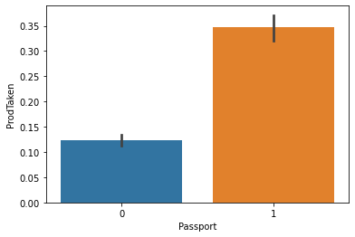

```python
sns.barplot(x=tour["Passport"], y=tour["ProdTaken"])
```

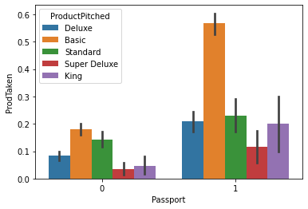

```python
sns.barplot(x=tour_orig.Passport,y=tour_orig.ProdTaken,hue=tour_orig.ProductPitched)
```

Customers with a passport are much more likely to purchas a package. Perhaps packages to foreign countries are convenient, and could sell easier, as they might be able to help navigating unfamiliar territories, or help tourists feel more at ease if they don't speak the local language to the place they are visiting.

For each product pitched, having a passport increases chance of buying a package. The most successful product pitched for buying a package seems to be the basic package (20% vs 60% success rate if the customer has a passport).

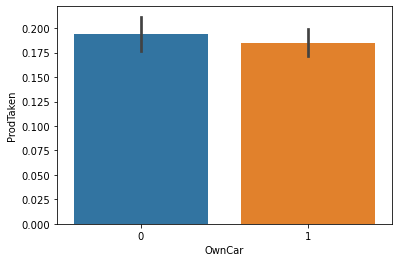

```python
sns.barplot(x=tour["OwnCar"], y=tour["ProdTaken"])
```

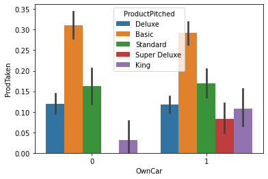

```python
sns.barplot(x=tour_orig.OwnCar,y=tour_orig.ProdTaken,hue=tour_orig.ProductPitched)
```

Owning a car does not seem to be related to purchasing a package.

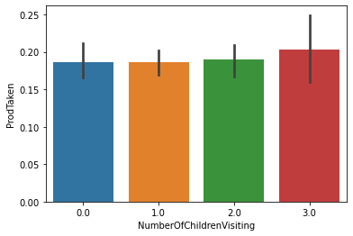

```python
sns.barplot(x=tour["NumberOfChildrenVisiting"], y=tour["ProdTaken"])
```

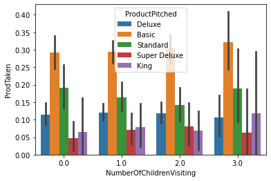

```python
sns.barplot(x=tour_orig.NumberOfChildrenVisiting,y=tour_orig.ProdTaken,hue=tour_orig.ProductPitched)
```

Number of children visiting doesn't seem to influence purchasing a package.

### Key takeaways for the marketing team from intial EDA are:

- Variation by package type is seen, therefore to be most effective we should identify which of these packages most closely resembles the wellness package to determine a more efficient marketing strategy

### Using the more general target variable of purchasing a package, we know:

-Younger ages may be more likely to purchase package

- A slightly longer pitch time can lead to more purchases, so train salesmen to slow down and make it personal
- A lower monthly income might lead to purchasing a package, so there is a market for getting a "deal", need to sell the value of the package and perhaps offer discounts when compared to purchasing items idividually

  -The company reaching out to customers proved to be effective for selling packages, so direct marketing is important
- city tier can be added as a target market variable (still not clear on if this is the city the customer lives in or the city they would like to visit, need clarity from the data owner)
- increasing followups showed to be successful for selling packages
- higher preferred property star led to increased purchasing of packages, again this could be leveraged to offer discounts to nicer hotels
- Given the relationship with the "number of trips" variable, we will most likely want two separating marketing campaigns, one for people who travel very infrequently (1-3 times) and one for people who travel a lot (7+). While the small number of trips is more frequent in our dataset (mode=2), we do see that those who travel a lot purchase packages more often, therefore two individualized campaigns could both show great success.

  -offering packages to foreign countries could be highly successful, given that having a passport greatly incrasese your chance of purchasing a package

# Bagging

Build a bagging classifier, random forrest, and decision tree

```python
list(tour)
```

```
['ProdTaken',
 'Age',
 'CityTier',
 'DurationOfPitch',
 'NumberOfPersonVisiting',
 'NumberOfFollowups',
 'PreferredPropertyStar',
 'NumberOfTrips',
 'Passport',
 'PitchSatisfactionScore',
 'OwnCar',
 'NumberOfChildrenVisiting',
 'MonthlyIncome',
 'TypeofContact_Company Invited',
 'TypeofContact_Self Enquiry',
 'Occupation_Large Business',
 'Occupation_Salaried',
 'Occupation_Small Business',
 'Gender_Female',
 'Gender_Male',
 'ProductPitched_Basic',
 'ProductPitched_Deluxe',
 'ProductPitched_King',
 'ProductPitched_Standard',
 'ProductPitched_Super Deluxe',
 'MaritalStatus_Divorced',
 'MaritalStatus_Married',
 'MaritalStatus_Single',
 'MaritalStatus_Unmarried',
 'Designation_AVP',
 'Designation_Executive',
 'Designation_Manager',
 'Designation_Senior Manager',
 'Designation_VP']
```

```python
#drop the target variables and the reference level for dummy variables (we had earlier
#set drop_first=false for EDA purposes, so we must drop then now)
x = tour.drop(['ProdTaken', 'TypeofContact_Self Enquiry', 'Occupation_Salaried',
                'Gender_Female','ProductPitched_Basic', 'MaritalStatus_Married',
                'Designation_Executive' ], axis=1)
y = tour['ProdTaken']
 #'Age',
 #'CityTier',
 #'DurationOfPitch',
 #'NumberOfPersonVisiting',
 #'NumberOfFollowups',
 #'PreferredPropertyStar',
 #'NumberOfTrips',
 #'Passport',
 #'PitchSatisfactionScore',
 #'OwnCar',
 #'NumberOfChildrenVisiting',
 #'MonthlyIncome',
 #'TypeofContact_Company Invited',
 #'Occupation_Large Business',
 #'Occupation_Small Business',
 #'Gender_Male',
 #'ProductPitched_Deluxe',
 #'ProductPitched_King',
 #'ProductPitched_Standard',
 #'ProductPitched_Super Deluxe',
 #'MaritalStatus_Divorced',
 #'MaritalStatus_Single',
 #'MaritalStatus_Unmarried',
 #'Designation_AVP',
 #'Designation_Manager',
 #'Designation_Senior Manager',
 #'Designation_VP',
```

```python
# Splitting data into training and test set:
x_train, x_test, y_train, y_test = train_test_split(x, y, test_size=0.3, random_state=1,stratify=y)
print(x_train.shape, x_test.shape)
```

```
(3421, 27) (1467, 27)
```

The number of variables remained the same. Verify that the original, test and train target variables have similar distributions.

```python
y.value_counts(1)
```

```
0    0.811784
1    0.188216
Name: ProdTaken, dtype: float64
```

```python
y_train.value_counts(1)
```

```
0    0.811751
1    0.188249
Name: ProdTaken, dtype: float64
```

```python
y_test.value_counts(1)
```

```
0    0.811861
1    0.188139
Name: ProdTaken, dtype: float64
```

## Model evaluation criterion

### The model can make wrong predictions as:

1. Predicting a person doesn't purchase a package, and they do purchase a package (false negative).
2. Predicting a person will purchase a package and they do not purchase a package (false positive).

### Which case is more important?

- To get the most value from marketing dollars we want to minimize the number of false positives.

### Which metric to optimize?

- We would want precision to be maximized, while considering balance in the other model performance measures as well.

```python
# defining a function to compute different metrics to check performance of a classification model built using sklearn
def model_performance_classification_sklearn(model, predictors, target):
    """
    Function to compute different metrics to check classification model performance

    model: classifier
    predictors: independent variables
    target: dependent variable
    """

    # predicting using the independent variables
    pred = model.predict(predictors)

    acc = accuracy_score(target, pred)  # to compute Accuracy
    recall = recall_score(target, pred)  # to compute Recall
    precision = precision_score(target, pred)  # to compute Precision
    f1 = f1_score(target, pred)  # to compute F1-score

    # creating a dataframe of metrics
    df_perf = pd.DataFrame(
        {
            "Accuracy": acc,
            "Recall": recall,
            "Precision": precision,
            "F1": f1,
        },
        index=[0],
    )

    return df_perf
```

```python
def confusion_matrix_sklearn(model, predictors, target):
    """
    To plot the confusion_matrix with percentages

    model: classifier
    predictors: independent variables
    target: dependent variable
    """
    y_pred = model.predict(predictors)
    cm = confusion_matrix(target, y_pred)
    labels = np.asarray(
        [
            ["{0:0.0f}".format(item) + "\n{0:.2%}".format(item / cm.flatten().sum())]
            for item in cm.flatten()
        ]
    ).reshape(2, 2)

    plt.figure(figsize=(6, 4))
    sns.heatmap(cm, annot=labels, fmt="")
    plt.ylabel("True label")
    plt.xlabel("Predicted label")
```

# Decision Tree

```
Training performance:
    Accuracy  Recall  Precision   F1
0       1.0     1.0        1.0  1.0
Testing performance:
    Accuracy    Recall  Precision        F1
0  0.883436  0.673913   0.696629  0.685083
```

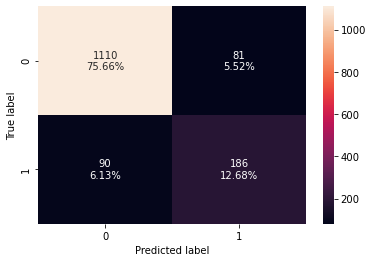

```python
#Fitting the model
d_tree = DecisionTreeClassifier(random_state=1)
d_tree.fit(x_train,y_train)

#Calculating different metrics
dtree_model_train_perf=model_performance_classification_sklearn(d_tree,x_train,y_train)
print("Training performance:\n",dtree_model_train_perf)
dtree_model_test_perf=model_performance_classification_sklearn(d_tree,x_test,y_test)
print("Testing performance:\n",dtree_model_test_perf)
#Creating confusion matrix
confusion_matrix_sklearn(d_tree, x_test, y_test)
```

As expected, the decision tree overfit the training data. The performance on the testing dataset should be improved.

# Random Forest

```
Training performance:
    Accuracy  Recall  Precision   F1
0       1.0     1.0        1.0  1.0
Testing performance:
    Accuracy   Recall  Precision        F1
0  0.913429  0.57971   0.935673  0.715884
```

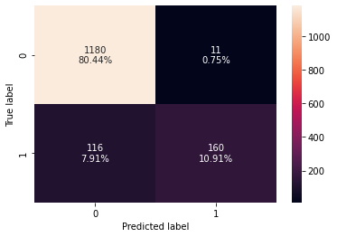

```python
#Fitting the model
rf_estimator = RandomForestClassifier(random_state=1)
rf_estimator.fit(x_train,y_train)

#Calculating different metrics
rf_estimator_model_train_perf=model_performance_classification_sklearn(rf_estimator,x_train,y_train)
print("Training performance:\n",rf_estimator_model_train_perf)
rf_estimator_model_test_perf=model_performance_classification_sklearn(rf_estimator,x_test,y_test)
print("Testing performance:\n",rf_estimator_model_test_perf)

#Creating confusion matrix
confusion_matrix_sklearn(rf_estimator, x_test, y_test)
```

Compared to the decision tree, the random forest has better precision, but the recall is decreased. Accuracy and F1 are comparable.

# Bagging Classifier

```
Training performance:
    Accuracy    Recall  Precision        F1
0  0.991523  0.956522   0.998379  0.977002
Testing performance:
    Accuracy    Recall  Precision        F1
0  0.890934  0.565217   0.795918  0.661017
```

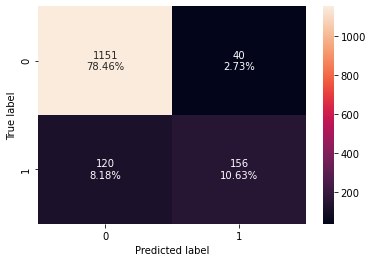

```python
#Fitting the model
bagging_classifier = BaggingClassifier(random_state=1)
bagging_classifier.fit(x_train,y_train)

#Calculating different metrics
bagging_classifier_model_train_perf=model_performance_classification_sklearn(bagging_classifier,x_train,y_train)
print("Training performance:\n",bagging_classifier_model_train_perf)
bagging_classifier_model_test_perf=model_performance_classification_sklearn(bagging_classifier,x_test,y_test)
print("Testing performance:\n",bagging_classifier_model_test_perf)
#Creating confusion matrix
confusion_matrix_sklearn(bagging_classifier, x_test, y_test)
```

The performance of the random forest appears to be the best. All performance measures were lower for the bagging classifier.

Each of these models can be tuned to evaluate enhanced performance.

# Tuning Decision Tree

```python
#Choose the type of classifier.
dtree_estimator = DecisionTreeClassifier(class_weight={0:0.35,1:0.65},random_state=1)

# Grid of parameters to choose from
parameters = {'max_depth': np.arange(2,10),
              'min_samples_leaf': [5, 7, 10, 15],
              'max_leaf_nodes' : [2, 3, 5, 10,15],
              'min_impurity_decrease': [0.0001,0.001,0.01,0.1]
             }

# Type of scoring used to compare parameter combinations
scorer = metrics.make_scorer(metrics.recall_score)

# Run the grid search
grid_obj = GridSearchCV(dtree_estimator, parameters, scoring=scorer,n_jobs=-1)
grid_obj = grid_obj.fit(x_train, y_train)

# Set the clf to the best combination of parameters
dtree_estimator = grid_obj.best_estimator_

# Fit the best algorithm to the data.
dtree_estimator.fit(x_train, y_train)
```

```
DecisionTreeClassifier(class_weight={0: 0.35, 1: 0.65}, max_depth=7,
                       max_leaf_nodes=15, min_impurity_decrease=0.0001,
                       min_samples_leaf=15, random_state=1)
```

```
Training performance:
    Accuracy    Recall  Precision        F1
0  0.828997  0.425466   0.560327  0.483672
Testing performance:
    Accuracy    Recall  Precision        F1
0  0.837082  0.434783   0.591133  0.501044
```

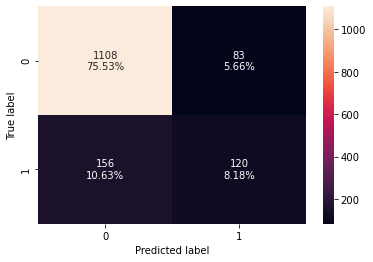

```python
#Calculating different metrics
dtree_estimator_model_train_perf=model_performance_classification_sklearn(dtree_estimator,x_train,y_train)
print("Training performance:\n",dtree_estimator_model_train_perf)
dtree_estimator_model_test_perf=model_performance_classification_sklearn(dtree_estimator,x_test,y_test)
print("Testing performance:\n",dtree_estimator_model_test_perf)
#Creating confusion matrix
confusion_matrix_sklearn(dtree_estimator, x_test, y_test)
```

# Tuning Random forest

```python
# Choose the type of classifier.
rf_tuned = RandomForestClassifier(class_weight={0:0.35,1:0.65},random_state=1)

parameters = {
                'max_depth': list(np.arange(3,5,1)),
                'max_features': np.arange(0.6,1.0,0.2),
                'max_samples': np.arange(0.7,1.1,0.2),
                'min_samples_split': np.arange(5,20 , 5),
                'n_estimators': np.arange(50,150,50),
                'min_impurity_decrease': [0.001,0.01,0.1]
}


# Type of scoring used to compare parameter combinations
scorer = metrics.make_scorer(metrics.recall_score)

# Run the grid search
grid_obj = GridSearchCV(rf_tuned, parameters, scoring=scorer,cv=5,n_jobs=-1)
grid_obj = grid_obj.fit(x_train, y_train)

# Set the clf to the best combination of parameters
rf_tuned = grid_obj.best_estimator_

# Fit the best algorithm to the data.
rf_tuned.fit(x_train, y_train)
```

```
RandomForestClassifier(class_weight={0: 0.35, 1: 0.65}, max_depth=4,
                       max_features=0.8, max_samples=0.8999999999999999,
                       min_impurity_decrease=0.001, min_samples_split=10,
                       random_state=1)
```

```
Training performance:
    Accuracy    Recall  Precision        F1
0  0.853259  0.409938   0.683938  0.512621
Testing performance:
    Accuracy   Recall  Precision        F1
0  0.853442  0.40942   0.684848  0.512472
```

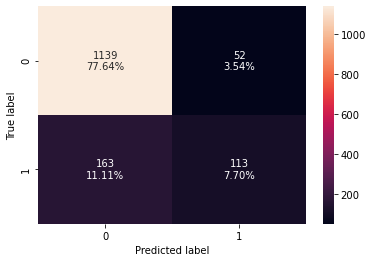

```python
#Calculating different metrics
rf_tuned_model_train_perf=model_performance_classification_sklearn(rf_tuned,x_train,y_train)
print("Training performance:\n",rf_tuned_model_train_perf)
rf_tuned_model_test_perf=model_performance_classification_sklearn(rf_tuned,x_test,y_test)
print("Testing performance:\n",rf_tuned_model_test_perf)

#Creating confusion matrix
confusion_matrix_sklearn(rf_tuned, x_test, y_test)
```

# Tuning Bagging Classifier

```python
# Choose the type of classifier.
bagging_estimator_tuned = BaggingClassifier(random_state=1)

# Grid of parameters to choose from
parameters = {'max_samples': [0.7,0.8,0.9],
              'max_features': [0.7,0.8,0.9],
              'n_estimators' : [10,20,30],
             }

# Type of scoring used to compare parameter combinations
acc_scorer = metrics.make_scorer(metrics.recall_score)

# Run the grid search
grid_obj = GridSearchCV(bagging_estimator_tuned, parameters, scoring=acc_scorer,cv=5)
grid_obj = grid_obj.fit(x_train, y_train)

# Set the clf to the best combination of parameters
bagging_estimator_tuned = grid_obj.best_estimator_

# Fit the best algorithm to the data.
bagging_estimator_tuned.fit(x_train, y_train)
```

```
BaggingClassifier(max_features=0.9, max_samples=0.9, n_estimators=30,
                  random_state=1)
```

```
Training performance:
    Accuracy    Recall  Precision        F1
0  0.998831  0.993789        1.0  0.996885
Testing performance:
    Accuracy    Recall  Precision        F1
0  0.910702  0.576087   0.919075  0.708241
```

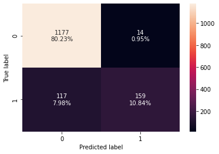

```python
#Calculating different metrics
bagging_estimator_tuned_model_train_perf=model_performance_classification_sklearn(bagging_estimator_tuned,x_train,y_train)
print("Training performance:\n",bagging_estimator_tuned_model_train_perf)
bagging_estimator_tuned_model_test_perf=model_performance_classification_sklearn(bagging_estimator_tuned,x_test,y_test)
print("Testing performance:\n",bagging_estimator_tuned_model_test_perf)

#Creating confusion matrix
confusion_matrix_sklearn(bagging_estimator_tuned, x_test, y_test)
```

```python
# training performance comparison

models_train_comp_df = pd.concat(
    [dtree_model_train_perf.T,dtree_estimator_model_train_perf.T,rf_estimator_model_train_perf.T,rf_tuned_model_train_perf.T,
     bagging_classifier_model_train_perf.T,bagging_estimator_tuned_model_train_perf.T],
    axis=1,
)
models_train_comp_df.columns = [
    "Decision Tree",
    "Decision Tree Estimator",
    "Random Forest Estimator",
    "Random Forest Tuned",
    "Bagging Classifier",
    "Bagging Estimator Tuned"]
print("Training performance comparison:")
models_train_comp_df
```

```
Training performance comparison:
```

|  | Decision Tree | Decision Tree Estimator | Random Forest Estimator | Random Forest Tuned | Bagging Classifier | Bagging Estimator Tuned |
| --- | --- | --- | --- | --- | --- | --- |
| Accuracy | 1.0 | 0.828997 | 1.0 | 0.853259 | 0.991523 | 0.998831 |
| Recall | 1.0 | 0.425466 | 1.0 | 0.409938 | 0.956522 | 0.993789 |
| Precision | 1.0 | 0.560327 | 1.0 | 0.683938 | 0.998379 | 1.000000 |
| F1 | 1.0 | 0.483672 | 1.0 | 0.512621 | 0.977002 | 0.996885 |

```python
# testing performance comparison

models_test_comp_df = pd.concat(
    [dtree_model_test_perf.T,dtree_estimator_model_test_perf.T,rf_estimator_model_test_perf.T,rf_tuned_model_test_perf.T,
     bagging_classifier_model_test_perf.T, bagging_estimator_tuned_model_test_perf.T],
    axis=1,
)
models_test_comp_df.columns = [
    "Decision Tree",
    "Decision Tree Estimator",
    "Random Forest Estimator",
    "Random Forest Tuned",
    "Bagging Classifier",
    "Bagging Estimator Tuned"]
print("Testing performance comparison:")
models_test_comp_df
```

```
Testing performance comparison:
```

|  | Decision Tree | Decision Tree Estimator | Random Forest Estimator | Random Forest Tuned | Bagging Classifier | Bagging Estimator Tuned |
| --- | --- | --- | --- | --- | --- | --- |
| Accuracy | 0.883436 | 0.837082 | 0.913429 | 0.853442 | 0.890934 | 0.910702 |
| Recall | 0.673913 | 0.434783 | 0.579710 | 0.409420 | 0.565217 | 0.576087 |
| Precision | 0.696629 | 0.591133 | 0.935673 | 0.684848 | 0.795918 | 0.919075 |
| F1 | 0.685083 | 0.501044 | 0.715884 | 0.512472 | 0.661017 | 0.708241 |

Precision is the measure that should be maximized, while ensuring a healthy balance of other performance measures.

The decision trees and tuned rnadom forest do not perform well.

The Random forest estimator and Tuned bagging classifier perform similarly. If we needed to choose between these models for implementation in a production environment, I would advice we choose the model that is simplest to code, implement, and maintain as they are performing at an equal level.

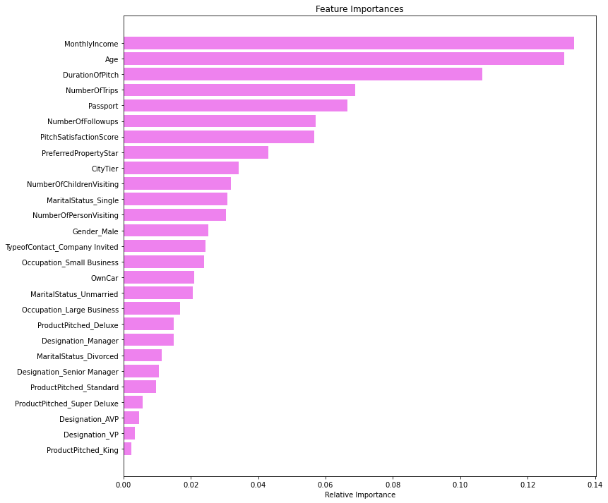

```python
#evaluate relative feature importance
feature_names = x_train.columns
importances = rf_estimator.feature_importances_
indices = np.argsort(importances)

plt.figure(figsize=(12,12))
plt.title('Feature Importances')
plt.barh(range(len(indices)), importances[indices], color='violet', align='center')
plt.yticks(range(len(indices)), [feature_names[i] for i in indices])
plt.xlabel('Relative Importance')
plt.show()
```

The top 5 most important features appear to be monthly income, age, duration of pitch, number of trips, and having a passport.

# Boosting

## Adaboost classifier

```
   Accuracy   Recall  Precision        F1
0  0.847705  0.32764   0.705686  0.447508
   Accuracy    Recall  Precision        F1
0  0.845262  0.322464   0.689922  0.439506
```

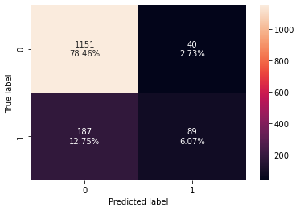

```python
#Fitting the model
ab_classifier = AdaBoostClassifier(random_state=1)
ab_classifier.fit(x_train,y_train)

#Calculating different metrics
ab_classifier_model_train_perf=model_performance_classification_sklearn(ab_classifier,x_train,y_train)
print(ab_classifier_model_train_perf)
ab_classifier_model_test_perf=model_performance_classification_sklearn(ab_classifier,x_test,y_test)
print(ab_classifier_model_test_perf)

#Creating confusion matrix
confusion_matrix_sklearn(ab_classifier,x_test,y_test)
```

### Adaboost Hyperparameter tuning

```python
# Choose the type of classifier.
abc_tuned = AdaBoostClassifier(random_state=1)

# Grid of parameters to choose from
parameters = {
    #Let's try different max_depth for base_estimator
    "base_estimator":[DecisionTreeClassifier(max_depth=1),DecisionTreeClassifier(max_depth=2),
                      DecisionTreeClassifier(max_depth=3)],
    "n_estimators": np.arange(10,80,10),
    "learning_rate":np.arange(0.2,1.6,0.2)
}

# Type of scoring used to compare parameter  combinations
scorer = metrics.make_scorer(metrics.f1_score)

# Run the grid search
grid_obj = GridSearchCV(abc_tuned, parameters, scoring=scorer,cv=5)
grid_obj = grid_obj.fit(x_train, y_train)

# Set the clf to the best combination of parameters
abc_tuned = grid_obj.best_estimator_

# Fit the best algorithm to the data.
abc_tuned.fit(x_train, y_train)
```

```
AdaBoostClassifier(base_estimator=DecisionTreeClassifier(max_depth=3),
                   n_estimators=70, random_state=1)
```

```
   Accuracy    Recall  Precision        F1
0  0.964338  0.857143   0.948454  0.900489
   Accuracy    Recall  Precision     F1
0  0.862304  0.539855   0.665179  0.596
```

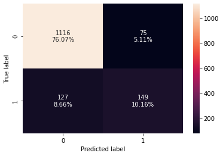

```python
#Calculating different metrics
abc_tuned_model_train_perf=model_performance_classification_sklearn(abc_tuned,x_train,y_train)
print(abc_tuned_model_train_perf)
abc_tuned_model_test_perf=model_performance_classification_sklearn(abc_tuned,x_test,y_test)
print(abc_tuned_model_test_perf)

#Creating confusion matrix
confusion_matrix_sklearn(abc_tuned,x_test,y_test)
```

## Gradient Boosting Classifier

```
Training performance:
    Accuracy    Recall  Precision        F1
0  0.882783  0.439441   0.876161  0.585315
Testing performance:
    Accuracy    Recall  Precision        F1
0  0.866394  0.387681   0.798507  0.521951
```

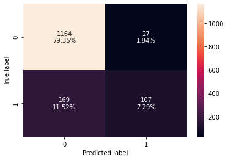

```python
#Fitting the model
gb_classifier = GradientBoostingClassifier(random_state=1)
gb_classifier.fit(x_train,y_train)

#Calculating different metrics
gb_classifier_model_train_perf=model_performance_classification_sklearn(gb_classifier,x_train,y_train)
print("Training performance:\n",gb_classifier_model_train_perf)
gb_classifier_model_test_perf=model_performance_classification_sklearn(gb_classifier,x_test,y_test)
print("Testing performance:\n",gb_classifier_model_test_perf)

#Creating confusion matrix
confusion_matrix_sklearn(gb_classifier,x_test,y_test)
```

### Gradient Boosting Hyperparameter tuning

```python
# Choose the type of classifier.
gbc_tuned = GradientBoostingClassifier(init=AdaBoostClassifier(random_state=1),random_state=1)

# Grid of parameters to choose from
parameters = {
    "n_estimators": [100,150,200,250],
    "subsample":[0.8,0.9,1],
    "max_features":[0.8,0.9,1]
}

# Type of scoring used to compare parameter combinations
scorer = metrics.make_scorer(metrics.f1_score)

# Run the grid search
grid_obj = GridSearchCV(gbc_tuned, parameters, scoring=scorer,cv=5)
grid_obj = grid_obj.fit(x_train, y_train)

# Set the clf to the best combination of parameters
gbc_tuned = grid_obj.best_estimator_

# Fit the best algorithm to the data.
gbc_tuned.fit(x_train, y_train)
```

```
GradientBoostingClassifier(init=AdaBoostClassifier(random_state=1),
                           max_features=0.9, n_estimators=250, random_state=1,
                           subsample=0.8)
```

```
Training performance:
    Accuracy    Recall  Precision        F1
0  0.916691  0.604037   0.928401  0.731891
Testing performance:
    Accuracy    Recall  Precision        F1
0  0.879346  0.474638   0.803681  0.596811
```

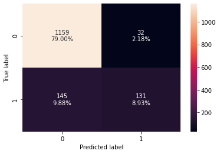

```python
#Calculating different metrics
gbc_tuned_model_train_perf=model_performance_classification_sklearn(gbc_tuned,x_train,y_train)
print("Training performance:\n",gbc_tuned_model_train_perf)
gbc_tuned_model_test_perf=model_performance_classification_sklearn(gbc_tuned,x_test,y_test)
print("Testing performance:\n",gbc_tuned_model_test_perf)

#Creating confusion matrix
confusion_matrix_sklearn(gbc_tuned,x_test,y_test)
```

# XG Boost Classifier

```
Training performance:
    Accuracy    Recall  Precision        F1
0  0.999708  0.998447        1.0  0.999223
Testing performance:
    Accuracy    Recall  Precision        F1
0  0.929789  0.710145   0.894977  0.791919
```

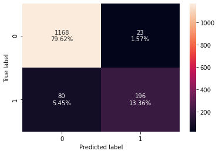

```python
#Fitting the model
xgb_classifier = XGBClassifier(random_state=1, eval_metric='logloss')
xgb_classifier.fit(x_train,y_train)

#Calculating different metrics
xgb_classifier_model_train_perf=model_performance_classification_sklearn(xgb_classifier,x_train,y_train)
print("Training performance:\n",xgb_classifier_model_train_perf)
xgb_classifier_model_test_perf=model_performance_classification_sklearn(xgb_classifier,x_test,y_test)
print("Testing performance:\n",xgb_classifier_model_test_perf)

#Creating confusion matrix
confusion_matrix_sklearn(xgb_classifier,x_test,y_test)
```

```python
#do not tune xgboost
```

# Stacking Classifier

```python
estimators = [('Random Forest',rf_tuned), ('Gradient Boosting',gbc_tuned), ('Decision Tree',dtree_estimator)]

#final_estimator = xgb_tuned

stacking_classifier= StackingClassifier(estimators=estimators)

stacking_classifier.fit(x_train,y_train)
```

```
StackingClassifier(estimators=[('Random Forest',
                                RandomForestClassifier(class_weight={0: 0.35,
                                                                     1: 0.65},
                                                       max_depth=4,
                                                       max_features=0.8,
                                                       max_samples=0.8999999999999999,
                                                       min_impurity_decrease=0.001,
                                                       min_samples_split=10,
                                                       random_state=1)),
                               ('Gradient Boosting',
                                GradientBoostingClassifier(init=AdaBoostClassifier(random_state=1),
                                                           max_features=0.9,
                                                           n_estimators=250,
                                                           random_state=1,
                                                           subsample=0.8)),
                               ('Decision Tree',
                                DecisionTreeClassifier(class_weight={0: 0.35,
                                                                     1: 0.65},
                                                       max_depth=7,
                                                       max_leaf_nodes=15,
                                                       min_impurity_decrease=0.0001,
                                                       min_samples_leaf=15,
                                                       random_state=1))])
```

```
Training performance:
    Accuracy    Recall  Precision        F1
0  0.917276  0.611801   0.922717  0.735761
Testing performance:
    Accuracy   Recall  Precision        F1
0  0.880709  0.48913   0.798817  0.606742
```

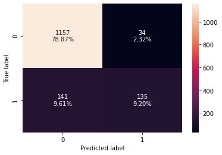

```python
#Calculating different metrics
stacking_classifier_model_train_perf=model_performance_classification_sklearn(stacking_classifier,x_train,y_train)
print("Training performance:\n",stacking_classifier_model_train_perf)
stacking_classifier_model_test_perf=model_performance_classification_sklearn(stacking_classifier,x_test,y_test)
print("Testing performance:\n",stacking_classifier_model_test_perf)

#Creating confusion matrix
confusion_matrix_sklearn(stacking_classifier,x_test,y_test)
```

# Compare all models

```python
# training performance comparison

models_train_comp_df = pd.concat(
    [dtree_model_train_perf.T,dtree_estimator_model_train_perf.T,rf_estimator_model_train_perf.T,rf_tuned_model_train_perf.T,
     bagging_classifier_model_train_perf.T,bagging_estimator_tuned_model_train_perf.T,ab_classifier_model_train_perf.T,
     abc_tuned_model_train_perf.T,gb_classifier_model_train_perf.T,gbc_tuned_model_train_perf.T,xgb_classifier_model_train_perf.T,
    stacking_classifier_model_train_perf.T],
    axis=1,
)
models_train_comp_df.columns = [
    "Decision Tree",
    "Decision Tree Estimator",
    "Random Forest Estimator",
    "Random Forest Tuned",
    "Bagging Classifier",
    "Bagging Estimator Tuned",
    "Adaboost Classifier",
    "Adabosst Classifier Tuned",
    "Gradient Boost Classifier",
    "Gradient Boost Classifier Tuned",
    "XGBoost Classifier",
    "Stacking Classifier"]
print("Training performance comparison:")
models_train_comp_df
```

```
Training performance comparison:
```

|  | Decision Tree | Decision Tree Estimator | Random Forest Estimator | Random Forest Tuned | Bagging Classifier | Bagging Estimator Tuned | Adaboost Classifier | Adabosst Classifier Tuned | Gradient Boost Classifier | Gradient Boost Classifier Tuned | XGBoost Classifier | Stacking Classifier |
| --- | --- | --- | --- | --- | --- | --- | --- | --- | --- | --- | --- | --- |
| Accuracy | 1.0 | 0.828997 | 1.0 | 0.853259 | 0.991523 | 0.998831 | 0.847705 | 0.964338 | 0.882783 | 0.916691 | 0.999708 | 0.917276 |
| Recall | 1.0 | 0.425466 | 1.0 | 0.409938 | 0.956522 | 0.993789 | 0.327640 | 0.857143 | 0.439441 | 0.604037 | 0.998447 | 0.611801 |
| Precision | 1.0 | 0.560327 | 1.0 | 0.683938 | 0.998379 | 1.000000 | 0.705686 | 0.948454 | 0.876161 | 0.928401 | 1.000000 | 0.922717 |
| F1 | 1.0 | 0.483672 | 1.0 | 0.512621 | 0.977002 | 0.996885 | 0.447508 | 0.900489 | 0.585315 | 0.731891 | 0.999223 | 0.735761 |

```python
# testing performance comparison



models_test_comp_df = pd.concat(
    [dtree_model_test_perf.T,dtree_estimator_model_test_perf.T,rf_estimator_model_test_perf.T,rf_tuned_model_test_perf.T,
     bagging_classifier_model_test_perf.T,bagging_estimator_tuned_model_test_perf.T,ab_classifier_model_test_perf.T,
     abc_tuned_model_test_perf.T,gb_classifier_model_test_perf.T,gbc_tuned_model_test_perf.T,xgb_classifier_model_test_perf.T,
    stacking_classifier_model_test_perf.T],
    axis=1,
)
models_test_comp_df.columns = [
    "Decision Tree",
    "Decision Tree Estimator",
    "Random Forest Estimator",
    "Random Forest Tuned",
    "Bagging Classifier",
    "Bagging Estimator Tuned",
    "Adaboost Classifier",
    "Adabosst Classifier Tuned",
    "Gradient Boost Classifier",
    "Gradient Boost Classifier Tuned",
    "XGBoost Classifier",
    "Stacking Classifier"]
print("Testing performance comparison:")
models_test_comp_df
```

```
Testing performance comparison:
```

|  | Decision Tree | Decision Tree Estimator | Random Forest Estimator | Random Forest Tuned | Bagging Classifier | Bagging Estimator Tuned | Adaboost Classifier | Adabosst Classifier Tuned | Gradient Boost Classifier | Gradient Boost Classifier Tuned | XGBoost Classifier | Stacking Classifier |
| --- | --- | --- | --- | --- | --- | --- | --- | --- | --- | --- | --- | --- |
| Accuracy | 0.883436 | 0.837082 | 0.913429 | 0.853442 | 0.890934 | 0.910702 | 0.845262 | 0.862304 | 0.866394 | 0.879346 | 0.929789 | 0.880709 |
| Recall | 0.673913 | 0.434783 | 0.579710 | 0.409420 | 0.565217 | 0.576087 | 0.322464 | 0.539855 | 0.387681 | 0.474638 | 0.710145 | 0.489130 |
| Precision | 0.696629 | 0.591133 | 0.935673 | 0.684848 | 0.795918 | 0.919075 | 0.689922 | 0.665179 | 0.798507 | 0.803681 | 0.894977 | 0.798817 |
| F1 | 0.685083 | 0.501044 | 0.715884 | 0.512472 | 0.661017 | 0.708241 | 0.439506 | 0.596000 | 0.521951 | 0.596811 | 0.791919 | 0.606742 |

While the precision measure is highest for the Tuned Bagging Estimator and the Random Forest, however the performance measures are more well balanced for the XG Boost Classifier.

I would recommend that the XG Boost Classifier be used to target customers who are likely to purchase a package.

# Variable importance

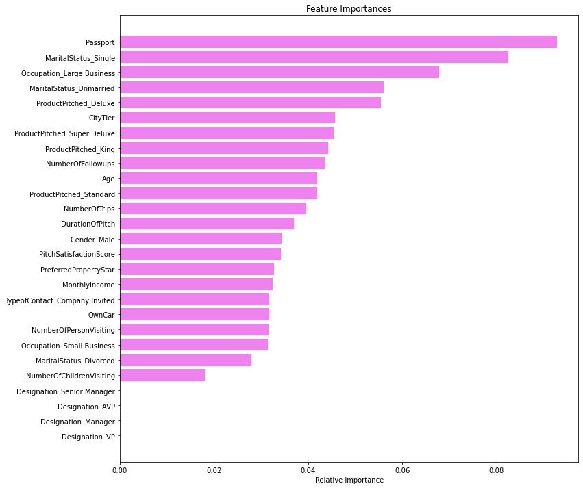

```python
feature_names = x_train.columns
importances = xgb_classifier.feature_importances_
indices = np.argsort(importances)

plt.figure(figsize=(12,12))
plt.title('Feature Importances')
plt.barh(range(len(indices)), importances[indices], color='violet', align='center')
plt.yticks(range(len(indices)), [feature_names[i] for i in indices])
plt.xlabel('Relative Importance')
plt.show()
```

# Final Recommendations

In order for the marketing team to launch a sucessful campaign to target customers who are likely to puchase a traveling package, they should rely upon the XG boost model.